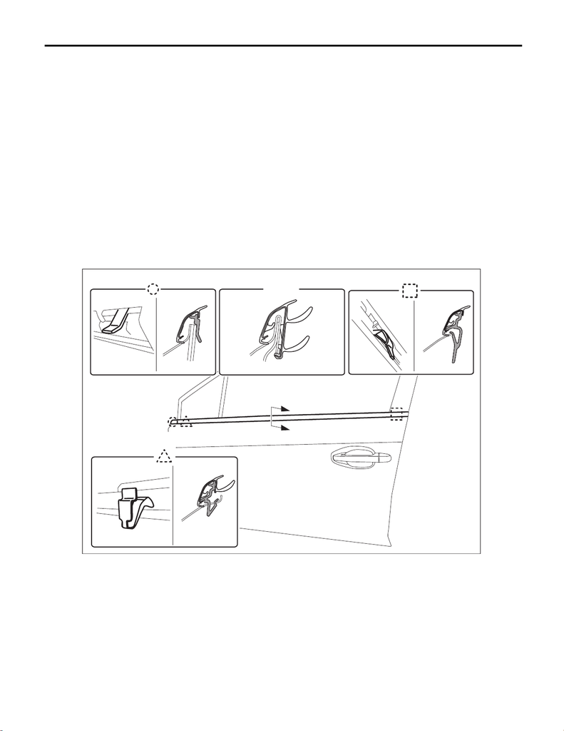

EB-42

Door Sash Tape

EXTERIOR BODY PANELS

8. Door Sash Tape

A: REMOVAL

1. FRONT DOOR

1) Disconnect the ground cable from battery and wait for at least 60 seconds before starting work. <Ref. to

NT-5, BATTERY, NOTE, Note.>

NOTE:

For models other than STI model, disconnect the ground terminal from battery sensor.

2) Remove the trim panel - front door. <Ref. to EI-56, FRONT DOOR, REMOVAL, Door Trim.>

3) Remove the outer mirror assembly. <Ref. to GW-26, REMOVAL, Outer Mirror Assembly.>

4) Remove the sealing cover - front door. <Ref. to EB-32, REMOVAL, Front Sealing Cover.>

5) Remove the glass assembly - front door. <Ref. to GW-19, REMOVAL, Front Door Glass.>

6) Remove the running channel - front door.

7) Remove the weather strip outer - front door.

CAUTION:

• When removing the weather strip outer, be careful not to damage the vehicle.

• Do not reuse the weather strip outer. Always replace with a new part.

8) Peel the door sash tape from the door sash.

NOTE:

• If the tape is difficult to detach, warm it by a hot air drier.

Use a household hairdryer. Do not use industrial dryers.

• If tape residue is remaining on the door sash, wipe clean.

A-A

EB-00751

A-A

15WRX_STI_US_EN.book 42 ページ ２０１５年２月１３日 金曜日 午前１１時２０分

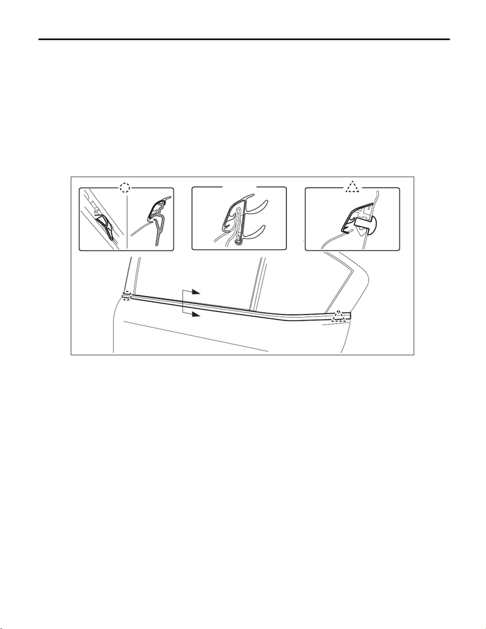

EB-43

Door Sash Tape

EXTERIOR BODY PANELS

2. REAR DOOR

1) Disconnect the ground cable from battery. <Ref. to NT-5, BATTERY, NOTE, Note.>

NOTE:

For models other than STI model, disconnect the ground terminal from battery sensor.

2) Remove the trim panel - rear door. <Ref. to EI-57, REAR DOOR, REMOVAL, Door Trim.>

3) Remove the sealing cover - rear door. <Ref. to EB-41, REMOVAL, Rear Sealing Cover.>

4) Remove the glass assembly - rear door. <Ref. to GW-34, REMOVAL, Rear Door Glass.>

5) Remove the running channel - rear door.

6) Remove the weather strip outer - rear door.

CAUTION:

• When removing the weather strip outer, be careful not to damage the vehicle.

• Do not reuse the weather strip outer. Always replace with a new part.

7) Peel the door sash tape from the door sash.

NOTE:

• If the tape is difficult to detach, warm it by a hot air drier.

Use a household hairdryer. Do not use industrial dryers.

• If tape residue is remaining on the door sash, wipe clean.

EB-00975

A-A

A-A

15WRX_STI_US_EN.book 43 ページ ２０１５年２月１３日 金曜日 午前１１時２０分

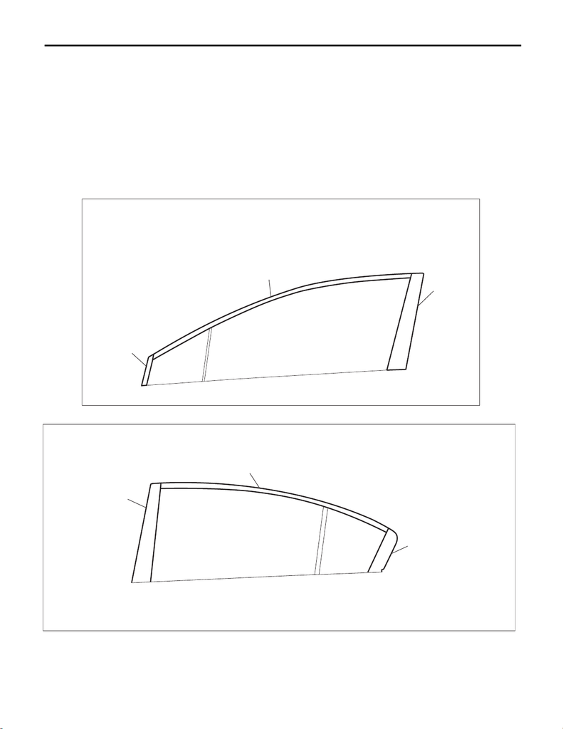

EB-44

Door Sash Tape

EXTERIOR BODY PANELS

B: INSTALLATION

CAUTION:

• Do not reuse the removed door sash tape. Replace it with a new tape.

• Press evenly along the sash when applying the tape using a spatula or similar object to make sure

no bubbles are formed.

If air bubbles are formed, reapply the tape.

• If the tape is wrinkled, etc. during application, replace the tape.

• Be sure to press the ends of the tape firmly to adhere securely. If the tape comes off at the ends or

where folded, the adhesive strength is weakened and the tape may peel off.

• There are locations where the tape ends will overlap each other. When applying the tape, be careful

of the order of their application.

• Front

• Rear

• Do not reuse the weather strip outer. Always replace with a new part.

EB-00827

(2)

(1)

(3)

(3)

(1)

(2)

EB-00976

15WRX_STI_US_EN.book 44 ページ ２０１５年２月１３日 金曜日 午前１１時２０分

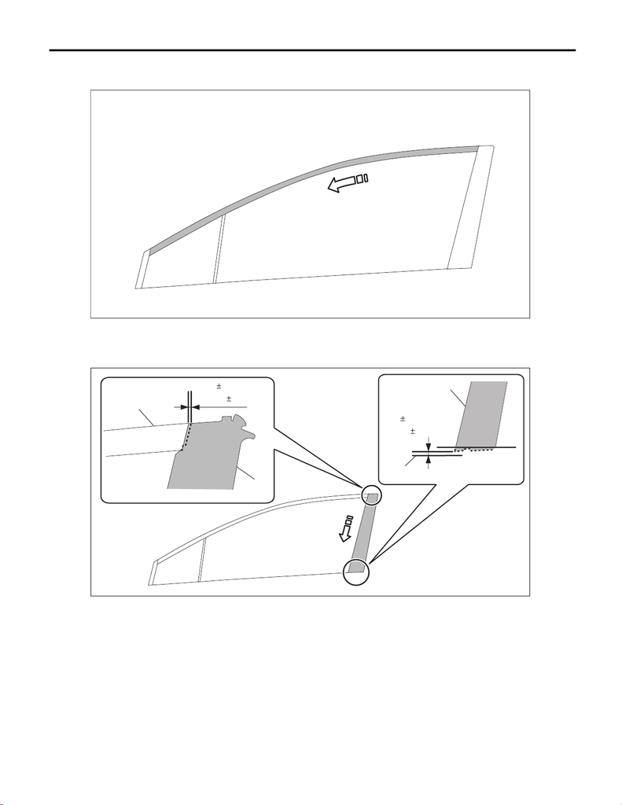

EB-45

Door Sash Tape

EXTERIOR BODY PANELS

1. FRONT DOOR

1) Apply the front door sash tape - medium from the rear of the vehicle towards the front.

2) Apply the front door sash tape - rear from the top of the vehicle towards the bottom.

NOTE:

Apply the end of the tape to the position shown in the figure.

(1) Front door sash tape - medium (2) Front door sash tape - rear (3) End of panel outer

EB-00777

EB-00778

(3)

(2)

(1)

(2)

(0.10 0.06 in)

2.5 1.5 mm

(0.09 0.04 in)

2.2 1.0 mm

15WRX_STI_US_EN.book 45 ページ ２０１５年２月１３日 金曜日 午前１１時２０分

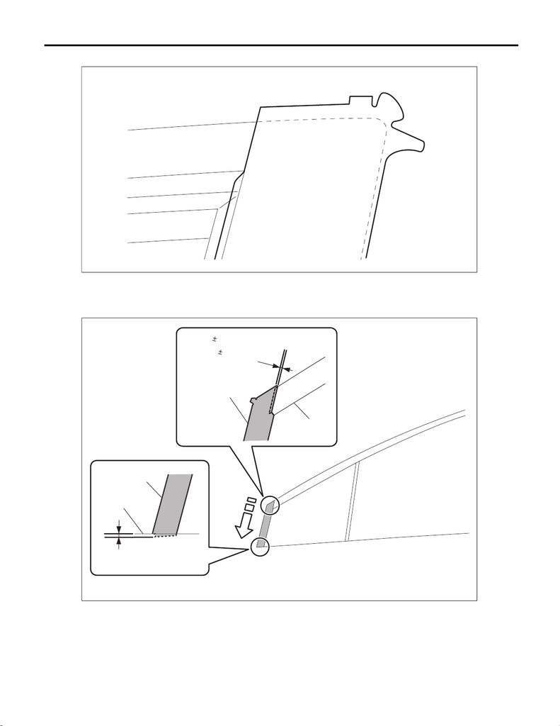

EB-46

Door Sash Tape

EXTERIOR BODY PANELS

3) Fold the corners at the door upper end area in the order of (1) — (3).

4) Apply the front door sash tape - front from the top of the vehicle towards the bottom.

NOTE:

Apply the end of the tape to the position shown in the figure.

(1) End of panel outer (2) Front door sash tape - front (3) Front door sash tape - medium

(1)

(2)

(3)

EB-00734

(1)

(2)

(0.17 in)4.3 mm

(2)

(3)

(0.10 0.06 in)

2.5 1.5 mm

EB-00919

15WRX_STI_US_EN.book 46 ページ ２０１５年２月１３日 金曜日 午前１１時２０分

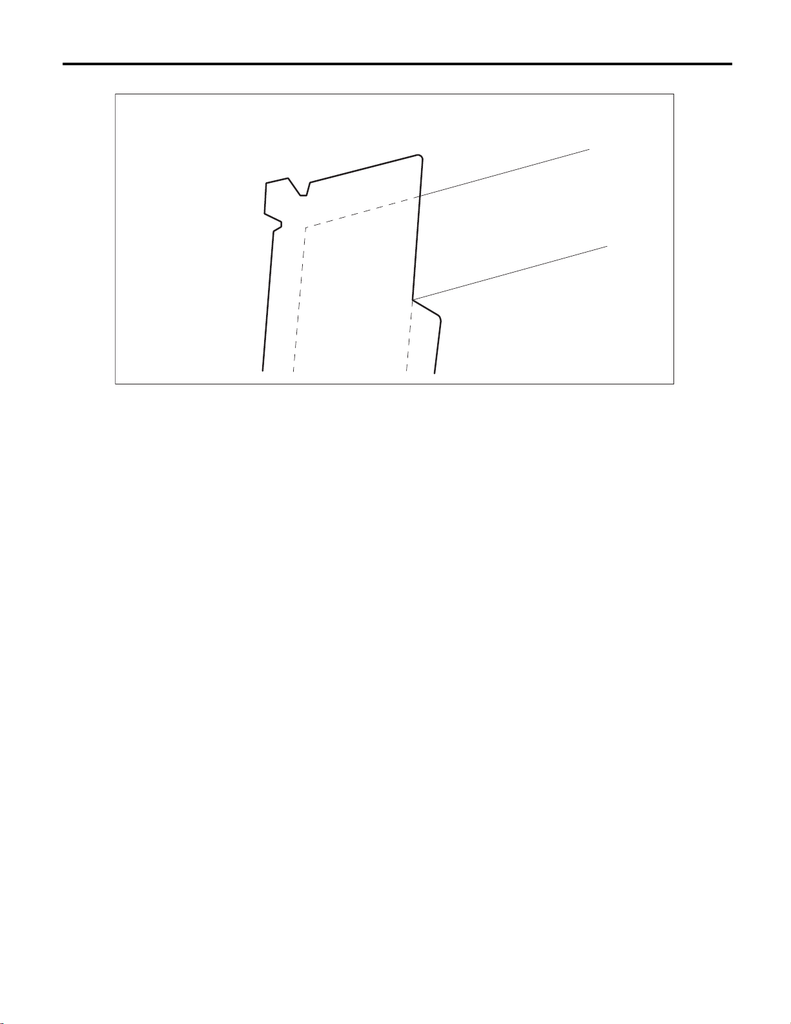

EB-47

Door Sash Tape

EXTERIOR BODY PANELS

5) Fold the corners at the door upper end area in the order of (1) — (3).

6) Install the weather strip outer - front door.

7) Install the running channel - front door.

8) Install the glass assembly - front door.

Tightening torque:

7.5 N·m (0.8 kgf-m, 5.5 ft-lb)

9) Install the sealing cover - front door.

10) Install the outer mirror assembly.

Tightening torque:

7.5 N·m (0.8 kgf-m, 5.5 ft-lb)

11) Install the trim panel - front door.

12) Connect the battery ground terminal. <Ref. to NT-5, BATTERY, NOTE, Note.>

NOTE:

For models other than STI model, connect the ground terminal to battery sensor.

13) When installing the panel assembly - front door, make sure that a uniform clearance is created around

the panel. For the dimension of clearance, refer to “SPECIFICATION” in “General Description”. <Ref. to EB-

2, SPECIFICATION, General Description.>

EB-00830

(1)

(2)

(3)

15WRX_STI_US_EN.book 47 ページ ２０１５年２月１３日 金曜日 午前１１時２０分

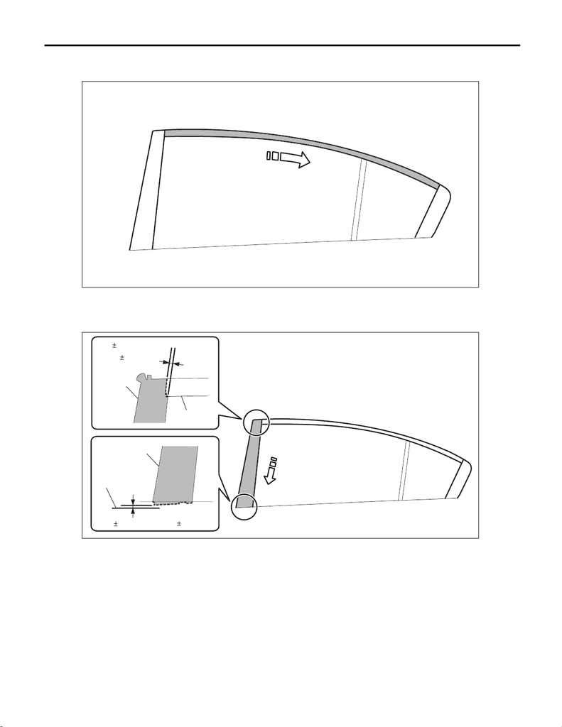

EB-48

Door Sash Tape

EXTERIOR BODY PANELS

2. REAR DOOR

1) Apply the rear door sash tape - medium from the front of the vehicle towards the rear.

2) Apply the rear door sash tape - front from the top of the vehicle towards the bottom.

NOTE:

Apply the end of the tape to the position shown in the figure.

(1) Rear door sash tape - medium (2) Rear door sash tape - front (3) End of panel outer

EB-00780

(3)

(2)

(2)

(1)

(0.10 0.06 in)

2.5 1.5 mm

(0.09 0.04 in)

2.2 1.0 mm

EB-00813

15WRX_STI_US_EN.book 48 ページ ２０１５年２月１３日 金曜日 午前１１時２０分

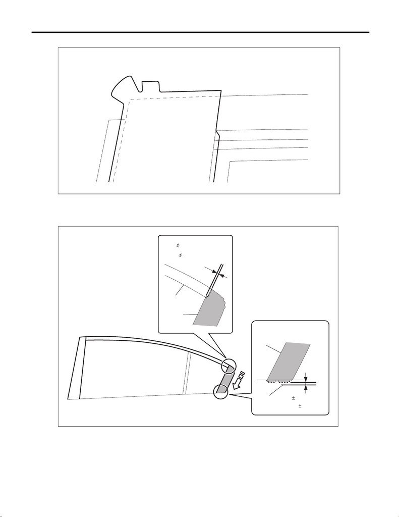

EB-49

Door Sash Tape

EXTERIOR BODY PANELS

3) Fold the corners at the door upper end area in the order of (1) — (2).

4) Apply the rear door sash tape - rear from the top of the vehicle towards the bottom.

NOTE:

Apply the end of the tape to the position shown in the figure.

(1) End of panel outer (2) Rear door sash tape - rear (3) Rear door sash tape - medium

(2)

(1)

EB-00782

(1)

(2)

(0.08 0.04 in)

2.1 1.0 mm

(2)

(3)

(0.10 0.06 in)

2.5 1.5 mm

EB-00815

15WRX_STI_US_EN.book 49 ページ ２０１５年２月１３日 金曜日 午前１１時２０分

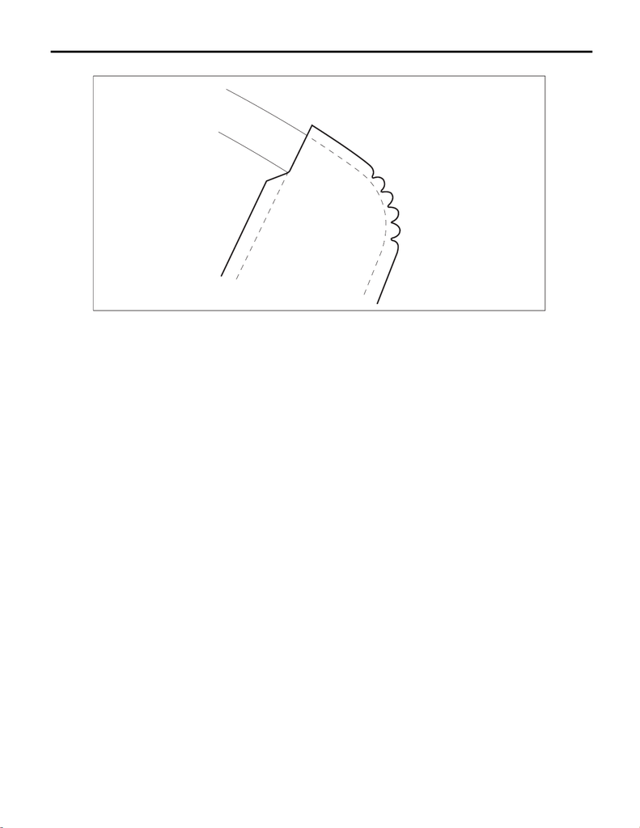

EB-50

Door Sash Tape

EXTERIOR BODY PANELS

5) Fold the corners at the door upper end area in the order of (1) — (3).

6) Install the weather strip outer - rear door.

7) Install the running channel - rear door.

8) Install the glass assembly - rear door.

Tightening torque:

7.5 N·m (0.8 kgf-m, 5.5 ft-lb)

9) Install the sealing cover - rear door.

10) Install the trim panel - rear door.

11) Connect the battery ground terminal. <Ref. to NT-5, BATTERY, NOTE, Note.>

NOTE:

For models other than STI model, connect the ground terminal to battery sensor.

2, SPECIFICATION, General Description.>

EB-00832

(1)

(2)

(3)

15WRX_STI_US_EN.book 50 ページ ２０１５年２月１３日 金曜日 午前１１時２０分